# Trabajo. Gráficas con ggplot2: consumo eléctrico de una vivienda..

Nombre:

En este trabajo, tenéis que completar algunos de los bloques de código para contestar a las preguntas que van apareciendo en el documento.

Empezaremos por cargar los paquetes “lubridate” (para manipular fechas), “dplyr” (para manipular data.frames) y “ggplot2” (para las gráficas).

```r
 ## completad aquí
```

Usaremos en este trabajo los datos que ya exploramos en el trabajo sobre dplyr. El fichero es [household-hourly-power-consumption.txt](https://aulavirtual.upct.es/mod/resource/view.php?id=93215), que se puede descargar del aula virtual.

## Importamos los datos

Lo importamos en un data.frame que llamaremos **vivienda**

```r
 ### insertar el código para importar:
```

La descripción del conjunto es la siguiente:

Attribute Information:

1. DateHour: Date and hour in format yyyy-mm- dd hh:mm:ss
2. Global_active_power: household global minute-averaged active power (in kilowatt)
3. Global_reactive_power: household global minute-averaged reactive power (in kilowatt)
4. Voltage: minute-averaged voltage (in volt)
5. Global_intensity: household global minute-averaged current intensity (in ampere)
6. Sub_metering_1: energy sub-metering No. 1 (in watt-hour of active energy). It corresponds to the kitchen, containing mainly a dishwasher, an oven and a microwave (hot plates are not electric but gas powered).
7. Sub_metering_2: energy sub-metering No. 2 (in watt-hour of active energy). It corresponds to the laundry room, containing a washing-machine, a tumble-drier, a refrigerator and a light.
8. Sub_metering_3: energy sub-metering No. 3 (in watt-hour of active energy). It corresponds to an electric water-heater and an air-conditioner.

Contestar a la pregunta siguiente:

¿De qué tipo es cada columna del conjunto vivienda después de haberlo importado?

Transformamos ahora la columna Date, que es de tipo “character” en un objeto de tipo Fecha, para poder extraer automáticamente de esta columna características como año, mes, día del mes y día de la semana (lunes, martes, etc..). Para ello usamos las funciones del paquete “lubridate”.

```r
## nada que completar
vivienda  <- vivienda %>%
  mutate(DateHour = ymd_hms(DateHour),
         anyo = year(DateHour),
         mes = month(DateHour),
         diames = day(DateHour),
         diasemana = wday(DateHour, label=TRUE, abbr= FALSE),
         diaanyo = yday(DateHour),
         hora = hour(DateHour))
```

## Histograma de la potencia global activa

Empezaremos por representar un histograma de la potencia global activa. Para ello usaremos el geom, *geom_histogram*.

Indicación: par geom_histogram, es suficiente y necesario indicar la aestetic *x*. Cuál tiene que ser nuestra especificación de *x*?

```
## stat_bin: binwidth defaulted to range/30. Use 'binwidth = x' to adjust this.
```

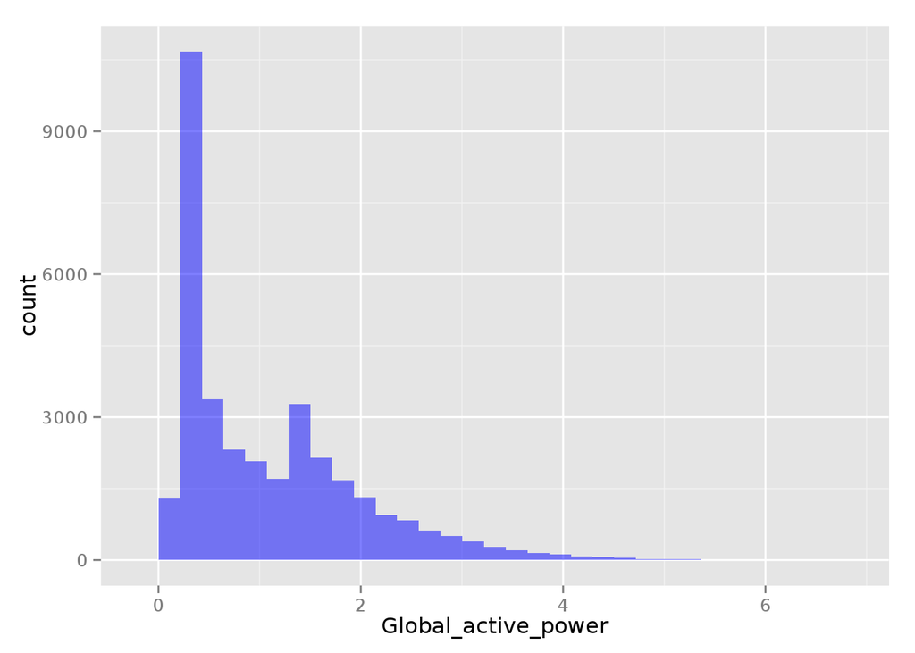

```r
 ## completad aquí para histograma de la potencia
```

## Boxplots del voltaje según los años.

Vamos a obtener ahora unos diagramas de cajabigotes del voltaje según cada año. Para ello usaremos el geom *geom_boxplot*. Necesitaremos especificar los “aesthetics” *x* e *y*.

Indicación: para el aesthetics *x*, usaremos anyo transformado en factor, con *x = factor(anyo)*.

```r
 ## completad aquí
```

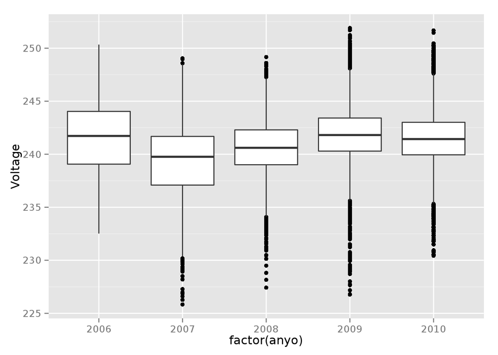

## Gráficas para la potencia global activa

Empezamos por representar la evolución temporal de la potencia global activa, usando ggplot.

```r
 ## completad aquí
```

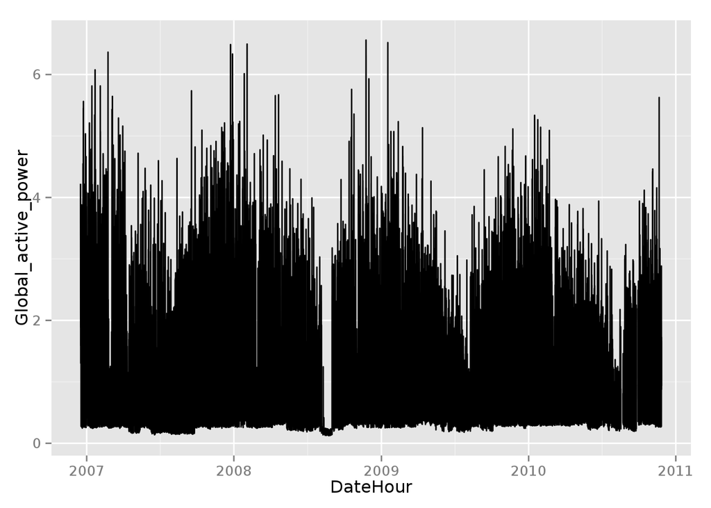

Se observa algo destacable?

### Pequeñas modificaciones de la gráfica:

Realizad las modificaciones siguientes sobre la gráfica temporal:

```r
 ## completad aquí
```

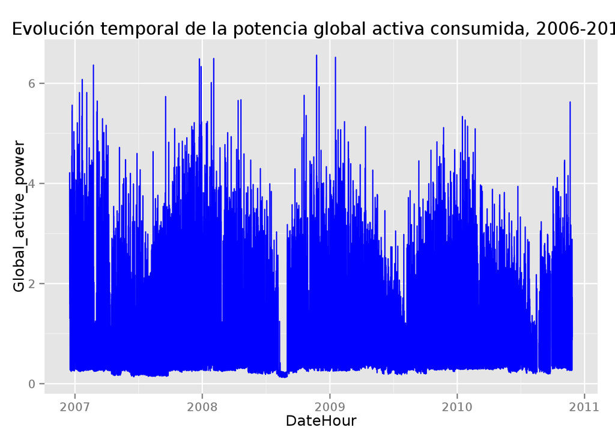

### Seleccionamos los meses de julio a diciembre de 2008

Realizar la misma gráfica pero si nos limitamos a los meses de julio hasta diciembre de 2008

```r
 ## completad aquí
```

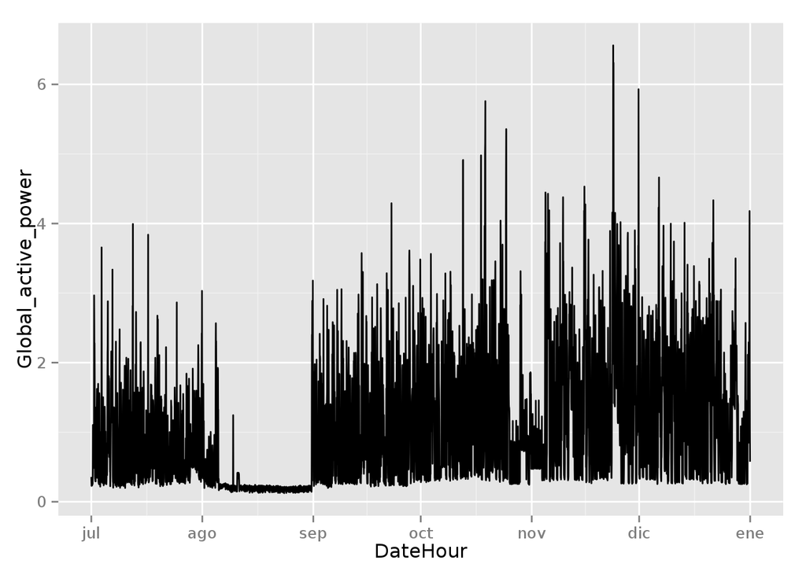

Veís algo destacable? ¿Teneís alguna explicación?

Queremos ahora representar *en una misma pantalla* los meses de julio, agosto y septiembre de los cuatro años de 2007 a 2010. Cada año debe aparecer en un panel diferente (pista: usaremos facet_grid).

```r
 ## completad aquí
```

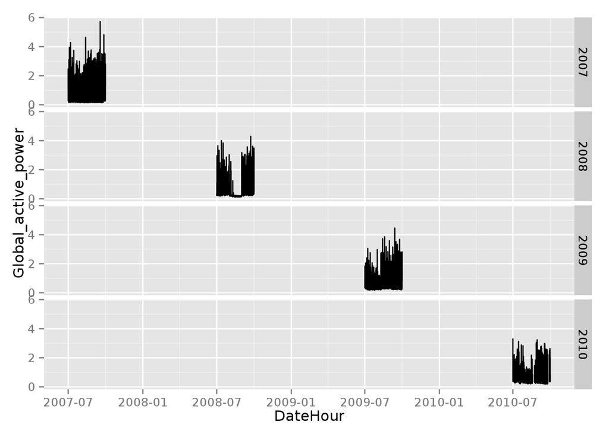

¿Habéis conseguido el resultado que esperábais?

> Para mejorar esta gráfica, introducimos un columna que sea el resultado de restar a DateHour el año asociado (tendremos entonces una fechatiempo “base” que pueda servir en la gráfica con distintos años).

Usad *mutate* para añadir a vivienda la columna DateHourBase que sea definida como *DateHour - years(anyo)*

```r
 ## completad aquí
```

Repetid la gráfica anterior usando *DateHourBase* en el eje Ox.

```r
 ## completad aquí
```

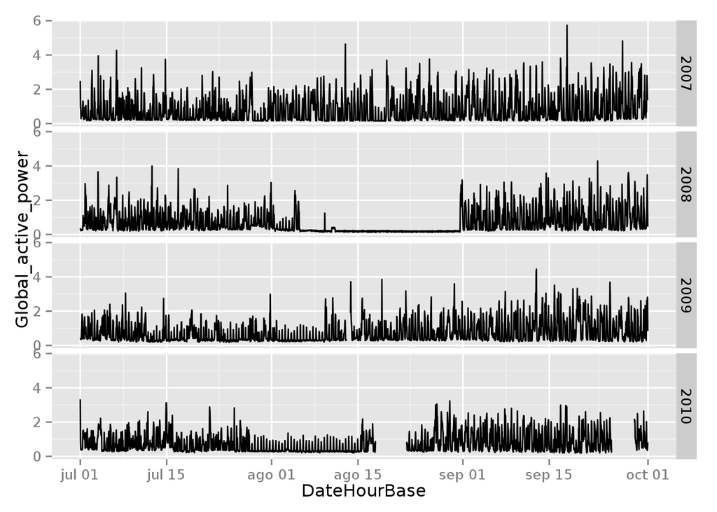

### Exploración del perfil horario de la potencia global consumida.

Vamos a explorar el perfil de evolución horario de la potencia global consumida.

Para ello, empezamos por construir usando los verbos de *dplyr* un conjunto que llamaremos *resumen.horario* y que contenga el valor promedio de la potencia global activa consumida por hora (el promedio se hará, por hora, sobre todo el conjunto *vivienda*).

*resumen.horario* debe contener tres columas: hora, Global_active_power (el promedio buscado), y n (el número de datos utilizado para calcular la media en cada grupo)

```r
 ## completad aquí
```

Podemos ahora representar gráficamente el perfil de evolución horario usando *resumen.horario* (Global_active_power en función de hora). Queremos hacerlo con barras verticales. Usaremos para ello *geom_bar*.  
Si obtenéis el error “Error : Mapping a variable to y and also using stat=”bin“”, tenéis que leer el mensaje de error completo para ver qué argumento debéis usar en *geom_bar*.

```r
 ## completad aquí
```

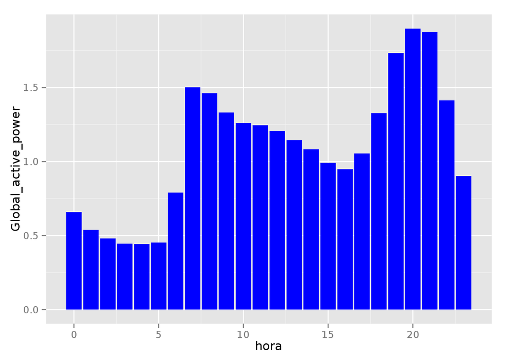

### Opcional:

Podemos añadir el valor de la potencia calculada encima de cada barra en la gráfica. Para ello podemos usar el geom_text. Empezad por leer la ayuda de geom_text o ver en la [documentación online](http://docs.ggplot2.org/current/geom_text.html):

```r
 ## completad aquí
```

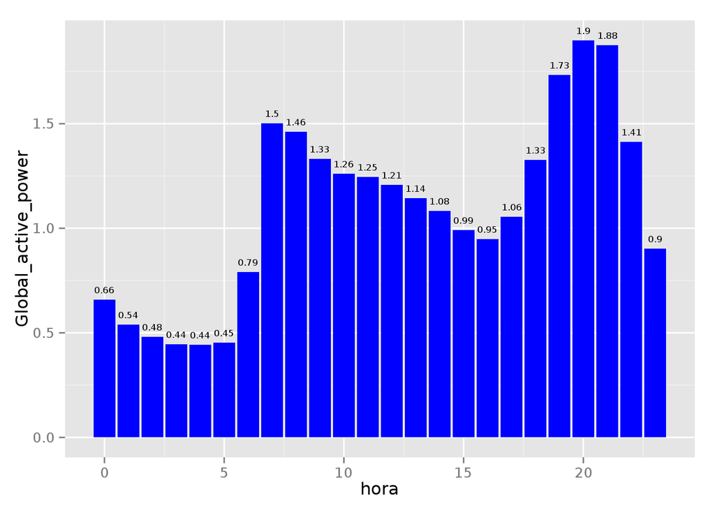

Otra opción, con las etiquetas en medio

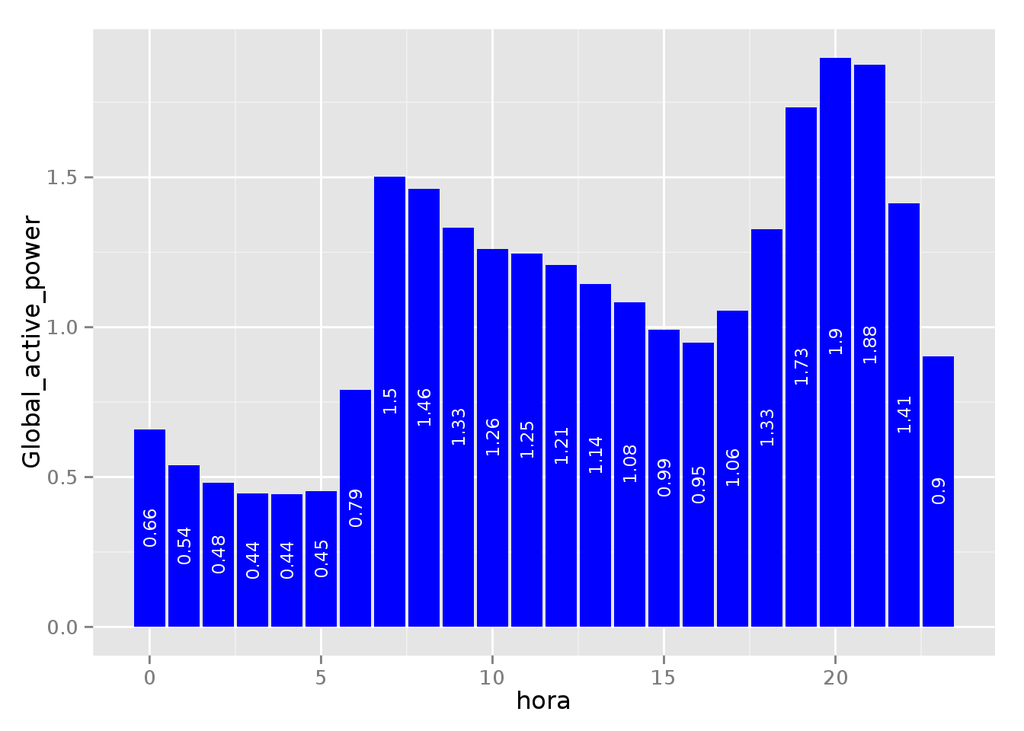

Vamos a ver si el perfil de evolución horaria es diferente según los días de la semana. Para ello, necesitamos crear un nuevo data.frame resumen, que se llamará *resumen.horario.dia*, y que contenga el promedio de la potencia global activa consumida si desglosamos los datos por hora *y por día de la semana*.

```r
 ## completad aquí
```

Ahora usaremos líneas (y no barras) para representar la evolución horaria de la potencia global consumida, queremos representar los distintos días en una misma gráfica, pero queremos usar una línea de un color diferente para cada día de la semana

```r
 ## completad aquí
```

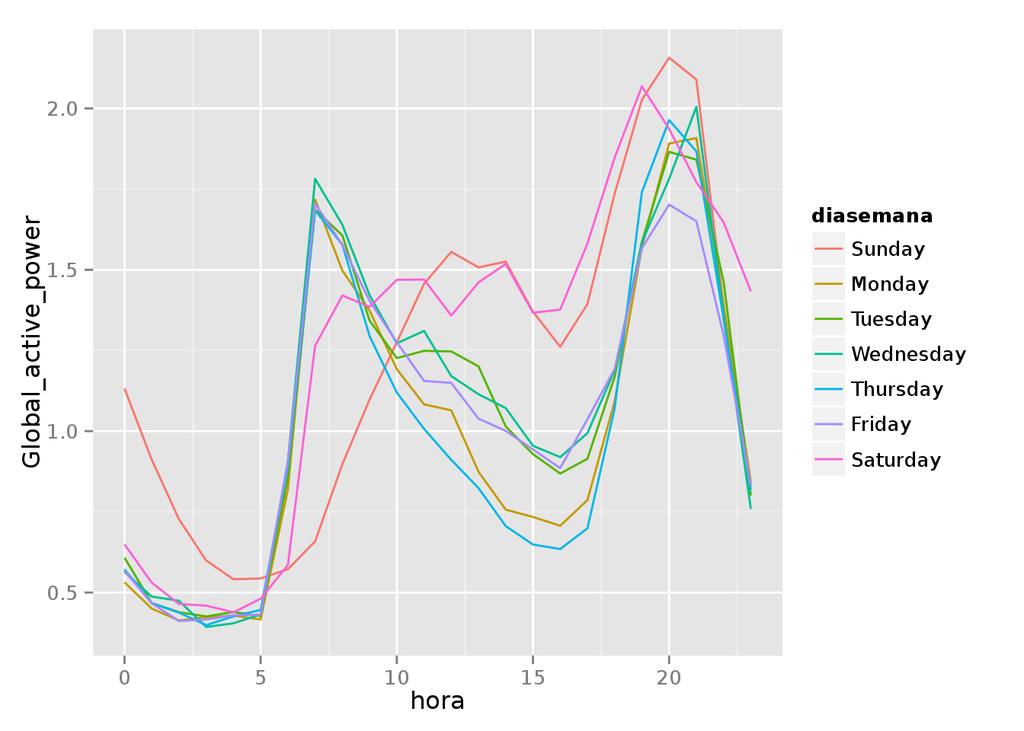

¿Algún rasgo destacable?